[figure not shown]

## mlcourse.ai – Open Machine Learning Course

Author: Mariya Mansurova, Analyst & developer in Yandex.Metrics team. Translated by Ivan Zakharov, ML enthusiast.  
This material is subject to the terms and conditions of the [Creative Commons CC BY-NC-SA 4.0](https://creativecommons.org/licenses/by-nc-sa/4.0/) license. Free use is permitted for any non-commercial purpose.

# Assignment #9 (demo)

## Time series analysis

**Same assignment as a [Kaggle Kernel](https://www.kaggle.com/kashnitsky/a9-demo-time-series-analysis) + solution.**

**Fill cells marked with "Your code here" and submit your answers to the questions through the [web form](https://docs.google.com/forms/d/1UYQ_WYSpsV3VSlZAzhSN_YXmyjV7YlTP8EYMg8M8SoM/edit).**

```python
import os
import warnings
warnings.filterwarnings('ignore')
import numpy as np
import pandas as pd

from plotly import __version__
from plotly.offline import download_plotlyjs, init_notebook_mode, plot, iplot
from plotly import graph_objs as go
import requests

print(__version__) # need 1.9.0 or greater
init_notebook_mode(connected = True)


def plotly_df(df, title = ''):
    data = []

    for column in df.columns:
        trace = go.Scatter(
            x = df.index,
            y = df[column],
            mode = 'lines',
            name = column
        )
        data.append(trace)

    layout = dict(title = title)
    fig = dict(data = data, layout = layout)
    iplot(fig, show_link=False)
```

```
4.4.1
```

## Data preparation

```python
df = pd.read_csv('../../data/wiki_machine_learning.csv', sep = ' ')
df = df[df['count'] != 0]
df.head()
```

|  | date | count | lang | page | rank | month | title |
| --- | --- | --- | --- | --- | --- | --- | --- |
| 81 | 2015-01-01 | 1414 | en | Machine_learning | 8708 | 201501 | Machine_learning |
| 80 | 2015-01-02 | 1920 | en | Machine_learning | 8708 | 201501 | Machine_learning |
| 79 | 2015-01-03 | 1338 | en | Machine_learning | 8708 | 201501 | Machine_learning |
| 78 | 2015-01-04 | 1404 | en | Machine_learning | 8708 | 201501 | Machine_learning |
| 77 | 2015-01-05 | 2264 | en | Machine_learning | 8708 | 201501 | Machine_learning |

```python
df.shape
```

```
(383, 7)
```

## Predicting with FB Prophet

```python
df.date = pd.to_datetime(df.date)
```

```python
plotly_df(df.set_index('date')[['count']])
```

[interactive chart not shown]

```python
from fbprophet import Prophet
```

```python
predictions = 30

df = df[['date', 'count']]
df.columns = ['ds', 'y']
df.tail()
```

|  | ds | y |
| --- | --- | --- |
| 382 | 2016-01-16 | 1644 |
| 381 | 2016-01-17 | 1836 |
| 376 | 2016-01-18 | 2983 |
| 375 | 2016-01-19 | 3389 |
| 372 | 2016-01-20 | 3559 |

```python
train_df = df[:-predictions].copy()
```

```python
m = Prophet()
m.fit(train_df)
```

```
INFO:numexpr.utils:NumExpr defaulting to 4 threads.
INFO:fbprophet:Disabling yearly seasonality. Run prophet with yearly_seasonality=True to override this.
INFO:fbprophet:Disabling daily seasonality. Run prophet with daily_seasonality=True to override this.
```

```
<fbprophet.forecaster.Prophet at 0x7fbe82adc0d0>
```

```python
future = m.make_future_dataframe(periods=predictions)
future.tail()
```

|  | ds |
| --- | --- |
| 378 | 2016-01-16 |
| 379 | 2016-01-17 |
| 380 | 2016-01-18 |
| 381 | 2016-01-19 |
| 382 | 2016-01-20 |

```python
preds = m.predict(future)
```

```python
preds.tail()
```

|  | ds | trend | yhat_lower | yhat_upper | trend_lower | trend_upper | additive_terms | additive_terms_lower | additive_terms_upper | weekly | weekly_lower | weekly_upper | multiplicative_terms | multiplicative_terms_lower | multiplicative_terms_upper | yhat |
| --- | --- | --- | --- | --- | --- | --- | --- | --- | --- | --- | --- | --- | --- | --- | --- | --- |
| 378 | 2016-01-16 | 2979.319903 | 1719.301404 | 2530.544878 | 2958.969208 | 2995.380753 | -861.693311 | -861.693311 | -861.693311 | -861.693311 | -861.693311 | -861.693311 | 0.0 | 0.0 | 0.0 | 2117.626592 |
| 379 | 2016-01-17 | 2984.727592 | 1863.416219 | 2660.658861 | 2962.781311 | 3001.710928 | -720.705354 | -720.705354 | -720.705354 | -720.705354 | -720.705354 | -720.705354 | 0.0 | 0.0 | 0.0 | 2264.022238 |
| 380 | 2016-01-18 | 2990.135281 | 2857.409897 | 3697.772697 | 2966.479507 | 3008.041191 | 281.357669 | 281.357669 | 281.357669 | 281.357669 | 281.357669 | 281.357669 | 0.0 | 0.0 | 0.0 | 3271.492950 |
| 381 | 2016-01-19 | 2995.542971 | 3120.905524 | 3932.522370 | 2970.790273 | 3014.400583 | 541.423837 | 541.423837 | 541.423837 | 541.423837 | 541.423837 | 541.423837 | 0.0 | 0.0 | 0.0 | 3536.966808 |
| 382 | 2016-01-20 | 3000.950660 | 3002.228089 | 3842.394217 | 2975.105970 | 3021.081775 | 425.547911 | 425.547911 | 425.547911 | 425.547911 | 425.547911 | 425.547911 | 0.0 | 0.0 | 0.0 | 3426.498570 |

**Question 1:** What is the prediction of the number of views of the wiki page on January 20? Round to the nearest integer.

- 4947
- 3426
- 5229
- 2744

## 3426

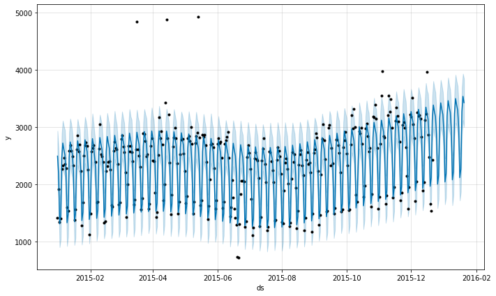

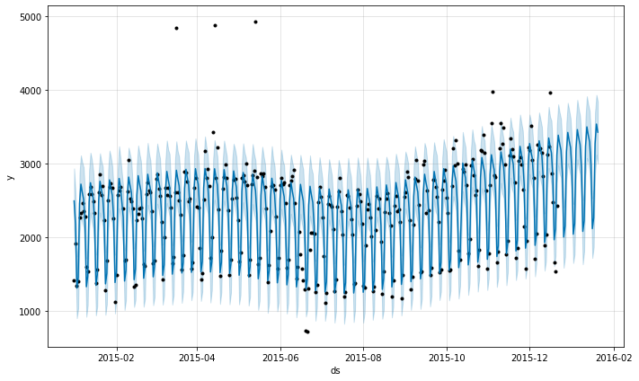

```python
m.plot(preds)
```

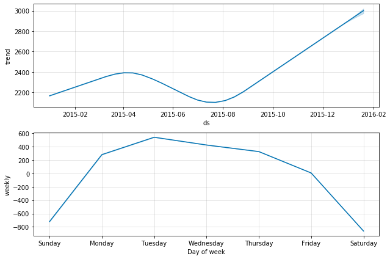

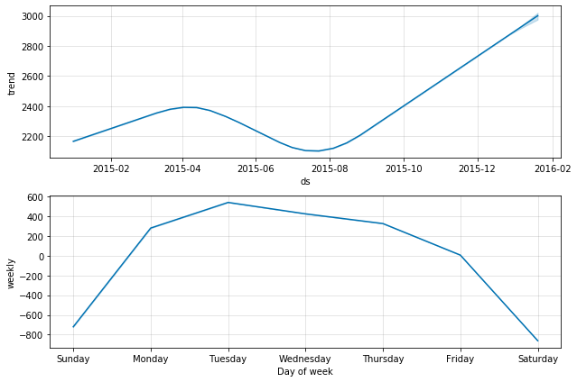

```python
m.plot_components(preds)
```

Estimate the quality of the prediction with the last 30 points.

```python
cmp_df = preds.set_index('ds')[['yhat', 'yhat_lower', 'yhat_upper']].join(df.set_index('ds'))
```

```python
cmp_df.head()
```

| ds | yhat | yhat_lower | yhat_upper | y |
| --- | --- | --- | --- | --- |
| 2015-01-01 | 2493.394569 | 2104.341926 | 2935.018677 | 1414 |
| 2015-01-02 | 2176.170858 | 1787.670121 | 2611.537626 | 1920 |
| 2015-01-03 | 1310.164121 | 902.604456 | 1740.620267 | 1338 |
| 2015-01-04 | 1453.891639 | 1033.850087 | 1885.951058 | 1404 |
| 2015-01-05 | 2458.694224 | 2053.498256 | 2885.707685 | 2264 |

```python
cmp_df.tail()
```

| ds | yhat | yhat_lower | yhat_upper | y |
| --- | --- | --- | --- | --- |
| 2016-01-16 | 2117.626592 | 1719.301404 | 2530.544878 | 1644 |
| 2016-01-17 | 2264.022238 | 1863.416219 | 2660.658861 | 1836 |
| 2016-01-18 | 3271.492950 | 2857.409897 | 3697.772697 | 2983 |
| 2016-01-19 | 3536.966808 | 3120.905524 | 3932.522370 | 3389 |
| 2016-01-20 | 3426.498570 | 3002.228089 | 3842.394217 | 3559 |

```python
cmp_df['e'] = cmp_df['y'] -cmp_df['yhat']
cmp_df['p'] = 100 * cmp_df['e'] / cmp_df['y']
```

```python
mape = np.mean(abs(cmp_df[-predictions:]['p']))
mae = np.mean(abs(cmp_df[-predictions:]['e']))
```

```python
mape, mae
```

```
(34.50292574049453, 599.8383194732162)
```

**Question 2: What is MAPE equal to?**

- 34.5
- 42.42
- 5.39
- 65.91

**Question 3: What is MAE equal to?**

- 355
- 4007
- 600
- 903

## 34.5, 600

## Predicting with ARIMA

```python
%matplotlib inline
import matplotlib.pyplot as plt
from scipy import stats
import statsmodels.api as sm
plt.rcParams['figure.figsize'] = (15, 10)
```

**Question 4: Let's verify the stationarity of the series using the Dickey-Fuller test. Is the series stationary? What is the p-value?**

- Series is stationary, p_value = 0.107
- Series is not stationary, p_value = 0.107
- Series is stationary, p_value = 0.001
- Series is not stationary, p_value = 0.001

## Series is not stationary, p_value = 0.107

```
Dickey-Fuller Test p=0.107392
```

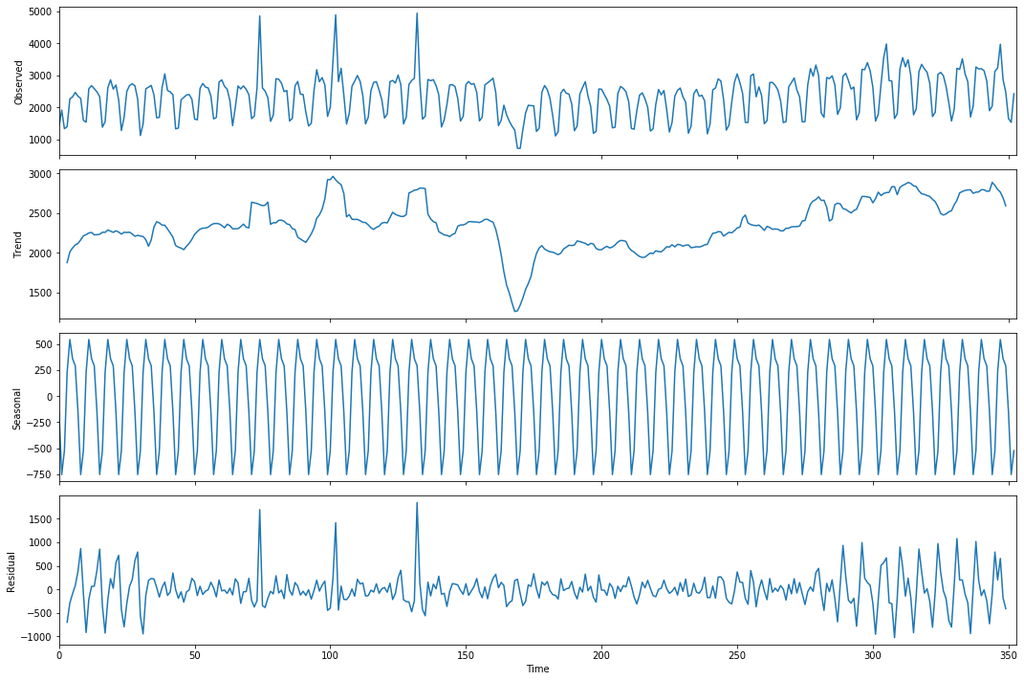

```python
sm.tsa.seasonal_decompose(train_df['y'].values, freq=7).plot()
print("Dickey-Fuller Test p=%f" % sm.tsa.stattools.adfuller(train_df['y'])[1])
```

```python
train_df.set_index('ds', inplace=True)
train_df['diff'] = train_df['y'] -train_df['y'].shift(7)
```

```
Dickey-Fuller Test p=0.000000
```

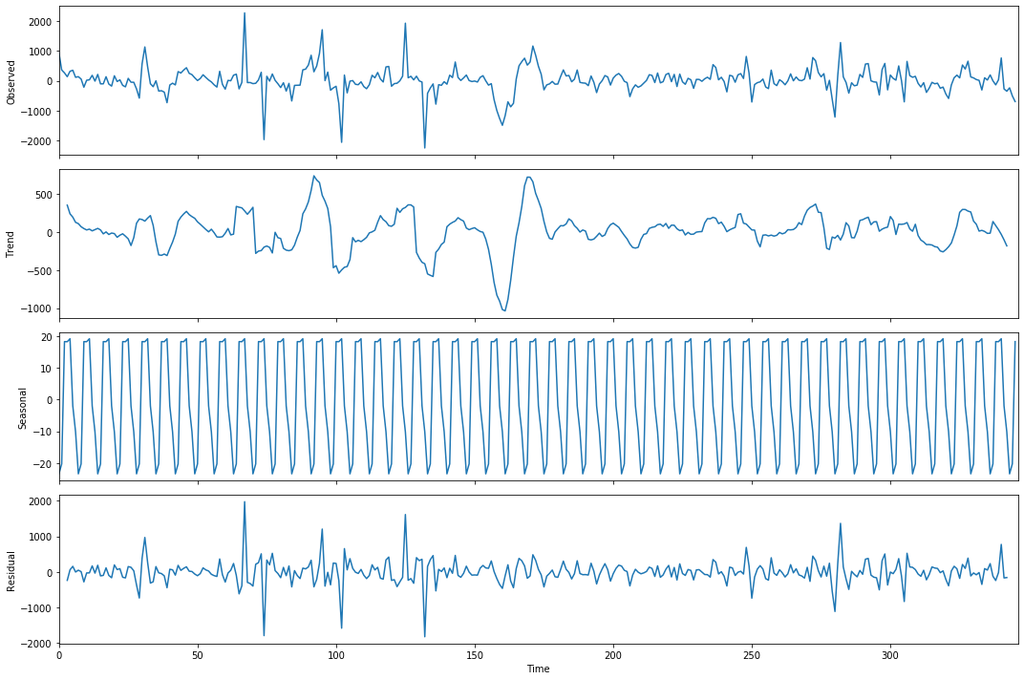

```python
sm.tsa.seasonal_decompose(train_df['diff'][7:].values, freq=7).plot()
print("Dickey-Fuller Test p=%f" % sm.tsa.stattools.adfuller(train_df['diff'][7:])[1])
```

```
Dickey-Fuller Test p=0.000000
```

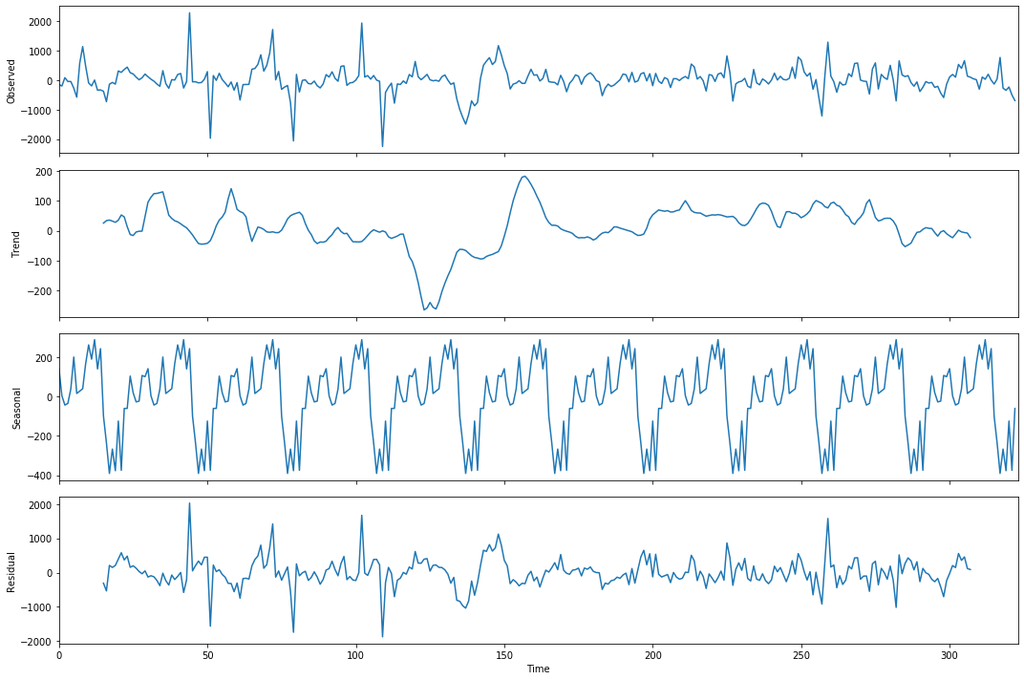

```python
train_df['diff_month'] = train_df['y'] -train_df['y'].shift(30)
sm.tsa.seasonal_decompose(train_df['diff'][30:].values, freq=30).plot()
print("Dickey-Fuller Test p=%f" % sm.tsa.stattools.adfuller(train_df['diff'][7:])[1])
```

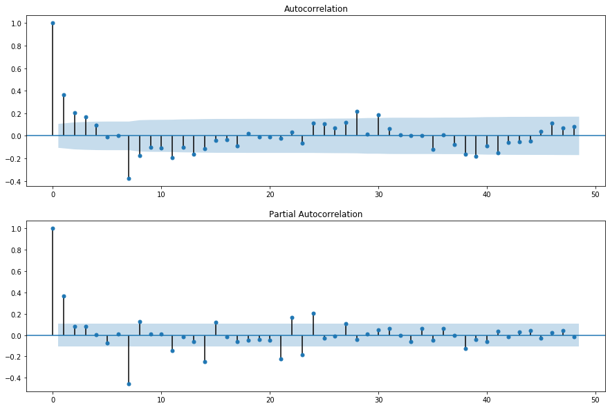

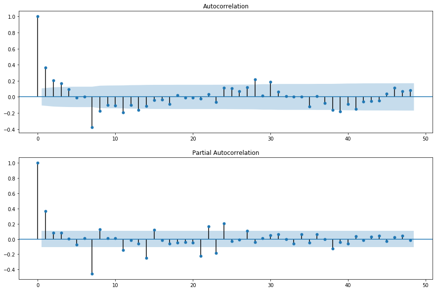

```python
ax = plt.subplot(211)
sm.graphics.tsa.plot_acf(train_df['diff'][13:].values.squeeze(), lags=48, ax=ax)

ax = plt.subplot(212)
sm.graphics.tsa.plot_pacf(train_df['diff'][13:].values.squeeze(), lags=48, ax=ax)
```

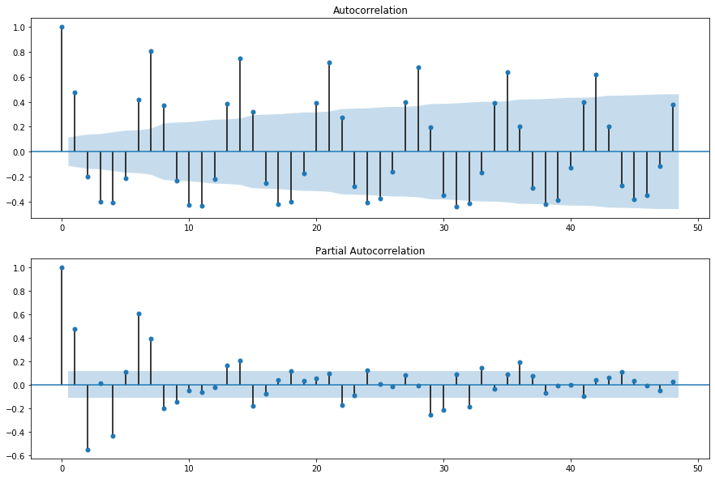

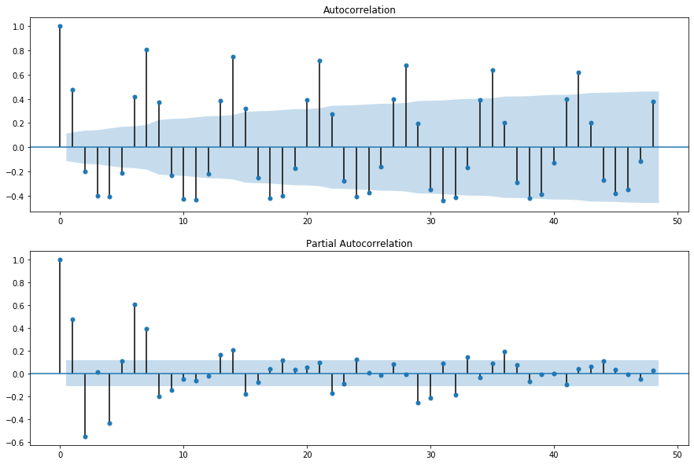

```python
ax = plt.subplot(211)
sm.graphics.tsa.plot_acf(train_df['diff_month'][59:].values.squeeze(), lags=48, ax=ax)

ax = plt.subplot(212)
sm.graphics.tsa.plot_pacf(train_df['diff_month'][59:].values.squeeze(), lags=48, ax=ax)
```

Next, we turn to the construction of the SARIMAX model (`sm.tsa.statespace.SARIMAX`).  
Question 5: What parameters are the best for the model according to the `AIC` criterion?

- D = 1, d = 0, Q = 0, q = 2, P = 3, p = 1
- D = 2, d = 1, Q = 1, q = 2, P = 3, p = 1
- D = 1, d = 1, Q = 1, q = 2, P = 3, p = 1
- D = 0, d = 0, Q = 0, q = 2, P = 3, p = 1

```python
ps = range(0, 2)
ds = range(0, 2)
qs = range(0, 3)
Ps = range(0, 4)
Ds = range(0, 3)
Qs = range(0, 2)
```

```python
from itertools import product
```

```python
parameters = product(ps, ds, qs, Ps, Ds, Qs)
parameter_list = list(parameters)
len(parameter_list)
```

```
288
```

```python
import warnings
from tqdm import tqdm_notebook
results1 = []
best_aic = float("inf")
warnings.filterwarnings('ignore')
```

```python
for param in tqdm_notebook(parameter_list):
    try:
        model = sm.tsa.statespace.SARIMAX(train_df['y'], order=(param[0], param[1], param[2]),\
                                         seasonal_order=(param[3], param[4], param[5], 7)).fit(disp=-1)
    except (ValueError, np.linalg.LinAlgError):
        continue

    aic = model.aic

    if aic < best_aic:
        best_aic = aic
        best_model = model
        best_param = param

    results1.append([param, aic])
```

```python
best_aic, best_param
```

```
(4961.632628496045, (0, 1, 2, 3, 2, 1))
```

```python
res = pd.DataFrame(results1)
res.columns = ['parameters', 'aic']
res = res.sort_values(by = 'aic', ascending=True)
res.head()
```

|  | parameters | aic |
| --- | --- | --- |
| 142 | (0, 1, 2, 3, 2, 1) | 4961.632628 |
| 261 | (1, 1, 1, 3, 2, 1) | 4962.830379 |
| 166 | (1, 0, 0, 3, 2, 1) | 4973.212241 |
| 70 | (0, 0, 2, 3, 2, 1) | 4980.827422 |
| 46 | (0, 0, 1, 3, 2, 1) | 4983.669858 |

```python
res[res['parameters'].isin([(1, 0, 2, 3, 1, 0),(1, 1, 2, 3, 2, 1),(1, 1, 2, 3, 1, 1),
                            (1, 0, 2, 3, 0, 0)])].sort_values(by='aic')
```

|  | parameters | aic |
| --- | --- | --- |
| 285 | (1, 1, 2, 3, 2, 1) | 4988.976967 |
| 283 | (1, 1, 2, 3, 1, 1) | 5019.555903 |
| 211 | (1, 0, 2, 3, 1, 0) | 5022.312524 |
| 209 | (1, 0, 2, 3, 0, 0) | 5183.811614 |

```python
import scipy.stats
```

```python
train_df['y_transf'], l = scipy.stats.boxcox(train_df['y'])
```

```python
l
```

```
0.7328410888410415
```

```python
def invboxcox(y, l):
    return np.exp(y) if l == 0 else np.exp(np.log(y * l + 1)/ l)
```

```python
results2 = []
best_aic = float("inf")
```

```python
for param in tqdm_notebook(parameter_list):
    try:
        model = sm.tsa.statespace.SARIMAX(train_df['y_transf'], order=(param[0], param[1], param[2]),\
                                         seasonal_order=(param[3], param[4], param[5], 7)).fit(disp=-1)
    except (ValueError, np.linalg.LinAlgError):
        continue

    aic = model.aic

    if aic < best_aic:
        best_aic = aic
        best_model = model
        best_param = param

    results2.append([param, aic])
```

```python
res = pd.DataFrame(results2)
res.columns = ['parameters', 'aic']
res = res.sort_values(by = 'aic', ascending=True)
res.head()
```

|  | parameters | aic |
| --- | --- | --- |
| 212 | (1, 0, 2, 3, 2, 1) | 3528.652679 |
| 165 | (1, 0, 0, 3, 2, 1) | 3530.524249 |
| 189 | (1, 0, 1, 3, 2, 1) | 3532.092279 |
| 260 | (1, 1, 1, 3, 2, 1) | 3534.434778 |
| 283 | (1, 1, 2, 3, 2, 1) | 3534.540192 |

```python
res[res['parameters'].isin([(1, 0, 2, 3, 1, 0),(1, 1, 2, 3, 2, 1),(1, 1, 2, 3, 1, 1),
                            (1, 0, 2, 3, 0, 0)])].sort_values(by='aic')
```

|  | parameters | aic |
| --- | --- | --- |
| 283 | (1, 1, 2, 3, 2, 1) | 3534.540192 |
| 209 | (1, 0, 2, 3, 1, 0) | 3556.880030 |
| 282 | (1, 1, 2, 3, 1, 1) | 3557.851314 |
| 208 | (1, 0, 2, 3, 0, 0) | 3674.915998 |

```python
best_aic, best_param
```

```
(3528.6526794346173, (1, 0, 2, 3, 2, 1))
```

```python
best_model.summary()
```

Statespace Model Results

| Dep. Variable: | y_transf | No. Observations: | 353 |
| --- | --- | --- | --- |
| Model: | SARIMAX(1, 0, 2)x(3, 2, 1, 7) | Log Likelihood | -1756.326 |
| Date: | Wed, 08 Jan 2020 | AIC | 3528.653 |
| Time: | 01:39:07 | BIC | 3559.261 |
| Sample: | 0 | HQIC | 3540.850 |
|  | - 353 |  |  |
| Covariance Type: | opg |  |  |

|  | coef | std err | z | P>\|z\| | [0.025 | 0.975] |
| --- | --- | --- | --- | --- | --- | --- |
| ar.L1 | 0.8176 | 0.118 | 6.914 | 0.000 | 0.586 | 1.049 |
| ma.L1 | -0.3332 | 0.125 | -2.675 | 0.007 | -0.577 | -0.089 |
| ma.L2 | -0.1998 | 0.091 | -2.186 | 0.029 | -0.379 | -0.021 |
| ar.S.L7 | -0.6471 | 0.039 | -16.453 | 0.000 | -0.724 | -0.570 |
| ar.S.L14 | -0.4317 | 0.059 | -7.364 | 0.000 | -0.547 | -0.317 |
| ar.S.L21 | -0.2667 | 0.043 | -6.198 | 0.000 | -0.351 | -0.182 |
| ma.S.L7 | -0.9996 | 3.018 | -0.331 | 0.740 | -6.914 | 4.915 |
| sigma2 | 1632.1778 | 4906.203 | 0.333 | 0.739 | -7983.803 | 1.12e+04 |

| Ljung-Box (Q): | 52.79 | Jarque-Bera (JB): | 529.54 |
| --- | --- | --- | --- |
| Prob(Q): | 0.08 | Prob(JB): | 0.00 |
| Heteroskedasticity (H): | 0.74 | Skew: | 0.95 |
| Prob(H) (two-sided): | 0.12 | Kurtosis: | 8.82 |

Warnings:  
[1] Covariance matrix calculated using the outer product of gradients (complex-step).

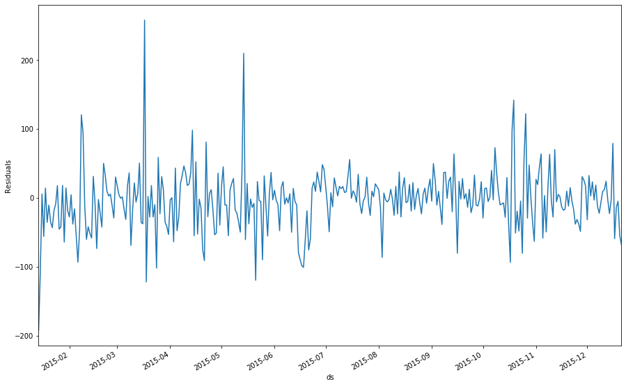

```python
best_model.resid[13:].plot()
plt.ylabel(u'Residuals')
```

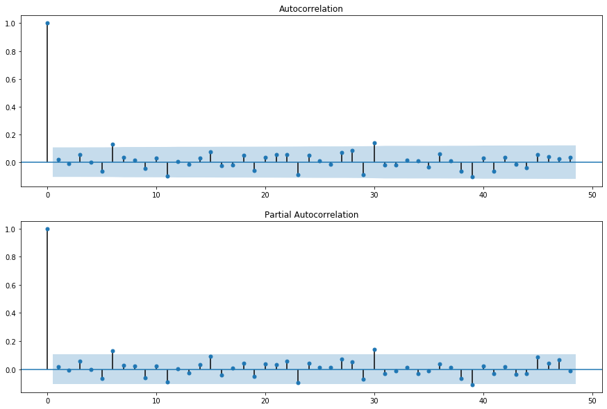

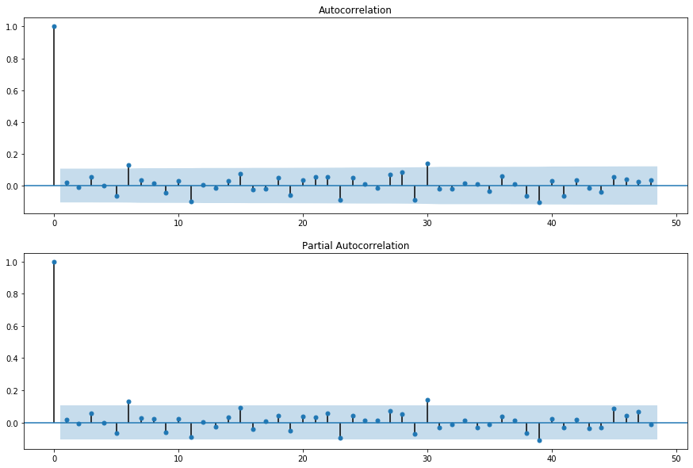

```python
ax = plt.subplot(211)
sm.graphics.tsa.plot_acf(best_model.resid[13:].values.squeeze(), lags=48, ax=ax)

ax = plt.subplot(212)
sm.graphics.tsa.plot_pacf(best_model.resid[13:].values.squeeze(), lags=48, ax=ax)
```

```python
print("Student's test: p=%f" % stats.ttest_1samp(best_model.resid[13:], 0)[1])
print("Dickey-Fuller test: p=%f" % sm.tsa.stattools.adfuller(best_model.resid[13:])[1])
```

```
Student's test: p=0.114945
Dickey-Fuller test: p=0.000000
```

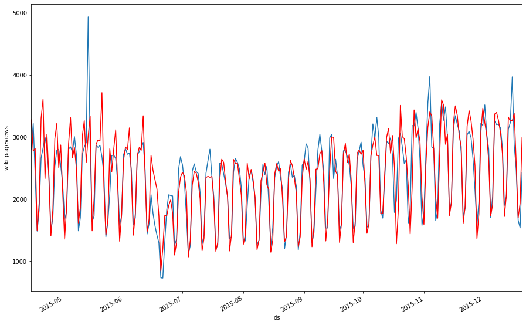

```python
train_df['y_inv'] = invboxcox(best_model.fittedvalues, l)

train_df.y.tail(250).plot()
train_df['y_inv'][13:].tail(250).plot(color='r')
plt.ylabel('wiki pageviews');
```